# Reported trouble sleeping in US adults

Dataset 10: NHANES adults (2009-10 and 2011-12 extract)

RSR feasibility analysis

2026-08-03

# Introduction

The National Health and Nutrition Examination Survey (NHANES) is a continuous cross-sectional survey of the civilian non-institutionalised US population, pairing a household interview with a standardised examination. This teaching extract holds 488 adults aged 21 to 80 from the 2009-10 and 2011-12 cycles, of whom 137 (28.1%) report having told a doctor about trouble sleeping. Sleep problems are common, under-treated, and tightly bound up with mental health and chronic disease, so knowing which characteristics mark higher prevalence is useful for primary-care case-finding.

**Aim.** Among these US adults, we examined which of age, sex, BMI, days of poor mental health, self-rated general health, recreational physical activity, smoking history and usual sleep duration are independently associated with having reported trouble sleeping to a doctor, mutually adjusting for the others.

This is a *Purpose 3* analysis: several predictors are of interest and the question is which remain associated with the outcome after mutual adjustment.

# Methods

**Data source.** NHANES 2009-10 and 2011-12, a complex multistage probability sample of the US civilian non-institutionalised population. This extract contains 488 adults with 31 variables. Sleep questions were asked in the household interview.

**Variables.** The outcome is `sleep_trouble`, a binary indicator where the **event is having told a doctor about trouble sleeping** (137 events in the full file). Predictors are age (years), sex (reference female), BMI (kg/m2), number of days of poor mental health in the past 30, self-rated general health collapsed to three levels (reference Excellent/Very good), recreational moderate or vigorous physical activity (reference no), ever having smoked 100 cigarettes (reference no) and usual sleep hours per night.

**Parameter budget.** There are 137 events in the file, which at ten events per parameter supports about 13 parameters. This model uses 9 (general health costs two, everything else one), comfortably inside the budget.

`weight_kg` and `height_cm` are excluded because `bmi` is exactly `weight_kg / (height_cm/100)^2` in this file; `obese` is excluded because it is exactly `bmi >= 30` and would duplicate BMI.

**Statistical analysis.** `glm(family = binomial)`, justified because the outcome is binary. We fitted a univariable model for each predictor first, then a single multivariable model containing all of them. Predictors were chosen in advance on subject-matter grounds, not by significance. Coefficients are exponentiated and reported as odds ratios with 95% confidence intervals; significance threshold 0.05. Model adequacy was assessed with `performance::check_model()`, focusing on binned residuals, collinearity, influential observations and events per parameter. Models are **unweighted**: the NHANES survey weights, strata and primary sampling units are not carried in this extract, so no result here is a nationally representative estimate. Analysis used R version 4.6.0 (2026-04-24) with tidyverse, gtsummary and performance.

**Missing data.** Complete-case analysis: 437 of 488 rows were analysed (51 dropped), leaving 123 events. The loss comes almost entirely from `general_health` and `days_ment_health_bad`, which are missing for the same 48 participants. Only 172 of 488 rows are complete on *every* variable in the file, so listwise deletion is a live threat and the complete-case N is reported for every model.

# Results

## Sample characteristics

**Table 1. Sample characteristics by reported sleep trouble.**

| **Characteristic** | **N** | **No sleep trouble** N = 314<sup>1</sup> | **Sleep trouble** N = 123<sup>1</sup> |
| --- | --- | --- | --- |
| Age (years) | 437 | 48 (35, 62) | 52 (43, 68) |
| Sex | 437 |  |  |
| Female |  | 146 (46%) | 81 (66%) |
| Male |  | 168 (54%) | 42 (34%) |
| BMI (kg/m2) | 437 | 28 (24, 33) | 30 (26, 35) |
| Poor mental health days (of 30) | 437 | 0 (0, 2) | 2 (0, 14) |
| Self-rated general health | 437 |  |  |
| Excellent/Very good |  | 164 (52%) | 39 (32%) |
| Good |  | 113 (36%) | 59 (48%) |
| Fair/Poor |  | 37 (12%) | 25 (20%) |
| Recreationally physically active | 437 | 159 (51%) | 57 (46%) |
| Ever smoked 100+ cigarettes | 437 | 132 (42%) | 69 (56%) |
| Sleep (hours/night) | 437 | 7.00 (6.00, 8.00) | 6.00 (5.00, 7.00) |

<sup>1</sup> Median (Q1, Q3); n (%)

Participants reporting sleep trouble are more often female, report many more days of poor mental health, rate their general health worse, sleep fewer hours per night and are more likely to have smoked. Age and BMI differ much less between the two groups.

## Exploratory figure

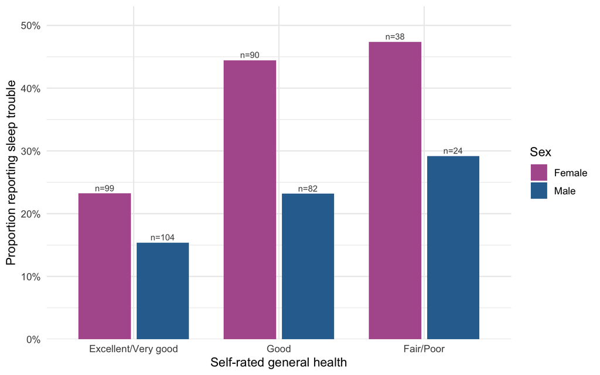

Figure 1. Proportion reporting sleep trouble by self-rated general health and sex.

Reported sleep trouble becomes more common as self-rated health worsens, and within every health category women report it more often than men - the two gradients appear roughly additive, which is what the model without an interaction assumes.

## Univariable models

| **Characteristic** | **N** | **OR** | **95% CI** | **p-value** |
| --- | --- | --- | --- | --- |
| Age (years) | 437 | 1.02 | 1.00, 1.03 | 0.013 |
| Sex | 437 |  |  |  |
| Female |  | — | — |  |
| Male |  | 0.45 | 0.29, 0.69 | <0.001 |
| BMI (kg/m2) | 437 | 1.04 | 1.01, 1.07 | 0.019 |
| Poor mental health days (of 30) | 437 | 1.07 | 1.04, 1.10 | <0.001 |
| Self-rated general health | 437 |  |  |  |
| Excellent/Very good |  | — | — |  |
| Good |  | 2.20 | 1.38, 3.53 | 0.001 |
| Fair/Poor |  | 2.84 | 1.53, 5.26 | <0.001 |
| Recreationally physically active | 437 |  |  |  |
| No |  | — | — |  |
| Yes |  | 0.84 | 0.55, 1.28 | 0.4 |
| Ever smoked 100+ cigarettes | 437 |  |  |  |
| No |  | — | — |  |
| Yes |  | 1.76 | 1.16, 2.69 | 0.008 |
| Sleep (hours/night) | 437 | 0.69 | 0.59, 0.82 | <0.001 |

Abbreviations: CI = Confidence Interval, OR = Odds Ratio

Most predictors are associated with the outcome crudely. Each additional day of poor mental health in the past 30 multiplies the odds of reported sleep trouble by OR 1.07 (95% CI 1.04 to 1.10) (p <0.001), which over a 10-day difference compounds to about 2.0-fold. Each additional hour of usual sleep is associated with OR 0.69 (95% CI 0.59 to 0.82) (p <0.001), a 30% lower odds per hour. Men have OR 0.45 (95% CI 0.29 to 0.69) (p <0.001) the odds of women. Worse self-rated health is associated with higher odds (Good OR 2.20 (95% CI 1.38 to 3.53), p = 0.001; Fair/Poor OR 2.84 (95% CI 1.53 to 5.26), p <0.001), and ever-smokers have OR 1.76 (95% CI 1.16 to 2.69) (p = 0.008). Age (OR 1.02 (95% CI 1.00 to 1.03)) and BMI (OR 1.04 (95% CI 1.01 to 1.07)) show weak but significant crude associations; physical activity shows none.

## Why adjustment is needed

**Days of poor mental health** is the dominant confounder of the general-health and smoking associations. Psychological distress is strongly associated with rating one’s overall health as Fair or Poor, is commoner among smokers, and is one of the principal causes of insomnia; a crude comparison across self-rated health categories therefore largely reflects the mental-health difference between them rather than anything about physical health. **Sex** is the second confounder: women in this sample report both more poor mental-health days and more sleep trouble, so the crude mental-health coefficient carries a sex component, and women’s higher BMI also contaminates the crude BMI association. **Sleep hours** confounds the general-health association in the same direction, because short sleepers rate their health worse. Mutual adjustment lets each odds ratio be read as a comparison between participants alike on the other measured characteristics - with the caveat that mental health and sleep trouble are so entangled that adjusting for one when studying the other is close to adjusting for a different manifestation of the same syndrome.

## Multivariable model

| **Characteristic** | **OR** | **95% CI** | **p-value** |
| --- | --- | --- | --- |
| Age (years) | 1.02 | 1.01, 1.04 | 0.003 |
| Sex |  |  |  |
| Female | — | — |  |
| Male | 0.45 | 0.28, 0.73 | 0.001 |
| BMI (kg/m2) | 1.02 | 0.99, 1.06 | 0.2 |
| Poor mental health days (of 30) | 1.06 | 1.03, 1.09 | <0.001 |
| Self-rated general health |  |  |  |
| Excellent/Very good | — | — |  |
| Good | 1.81 | 1.07, 3.07 | 0.026 |
| Fair/Poor | 1.51 | 0.74, 3.06 | 0.3 |
| Recreationally physically active |  |  |  |
| No | — | — |  |
| Yes | 1.33 | 0.82, 2.16 | 0.2 |
| Ever smoked 100+ cigarettes |  |  |  |
| No | — | — |  |
| Yes | 1.68 | 1.05, 2.70 | 0.030 |
| Sleep (hours/night) | 0.76 | 0.63, 0.90 | 0.002 |

Abbreviations: CI = Confidence Interval, OR = Odds Ratio

**Model fit: multivariable logistic model for sleep trouble**

| Statistic | Value |
| --- | --- |
| Complete-case N | 437 |
| Events (sleep trouble = 1) | 123 |
| Parameters (excl. intercept) | 9 |
| Events per parameter | 13.7 |
| AIC (null model) | 521.4 |
| AIC (full model) | 463.4 |
| Tjur's R-squared | 0.179 |

The model has 123 events for 9 estimated parameters, i.e. **13.7 events per parameter**, comfortably above the conventional minimum of ten. AIC falls from 521.4 for the intercept-only model to 463.4, a drop of 58.0; Tjur’s R-squared is 0.179.

Among participants alike on everything else, each additional day of poor mental health multiplies the odds of reported sleep trouble by OR 1.06 (95% CI 1.03 to 1.09) (p <0.001). Men have OR 0.45 (95% CI 0.28 to 0.73) the odds of otherwise-similar women (p = 0.001). Each additional hour of usual sleep is associated with OR 0.76 (95% CI 0.63 to 0.90) (p = 0.002), ever-smoking with OR 1.68 (95% CI 1.05 to 2.70) (p = 0.030), each year of age with OR 1.02 (95% CI 1.01 to 1.04) (p = 0.003), and rating one’s health Good rather than Excellent/Very good with OR 1.81 (95% CI 1.07 to 3.07) (p = 0.026). BMI (OR 1.02 (95% CI 0.99 to 1.06)) and physical activity (OR 1.33 (95% CI 0.82 to 2.16)) are not independently associated. These are associations among the participants observed, not effects of intervening.

## Unadjusted versus adjusted

**Table 2. Unadjusted and adjusted odds ratios.**

| **Characteristic** | **Unadjusted** **N** | **Unadjusted** **OR** | **Unadjusted** **95% CI** | **Unadjusted** **p-value** | **Adjusted** **OR** | **Adjusted** **95% CI** | **Adjusted** **p-value** |
| --- | --- | --- | --- | --- | --- | --- | --- |
| Age (years) | 437 | 1.02 | 1.00, 1.03 | 0.013 | 1.02 | 1.01, 1.04 | 0.003 |
| Sex | 437 |  |  |  |  |  |  |
| Female |  | — | — |  | — | — |  |
| Male |  | 0.45 | 0.29, 0.69 | <0.001 | 0.45 | 0.28, 0.73 | 0.001 |
| BMI (kg/m2) | 437 | 1.04 | 1.01, 1.07 | 0.019 | 1.02 | 0.99, 1.06 | 0.2 |
| Poor mental health days (of 30) | 437 | 1.07 | 1.04, 1.10 | <0.001 | 1.06 | 1.03, 1.09 | <0.001 |
| Self-rated general health | 437 |  |  |  |  |  |  |
| Excellent/Very good |  | — | — |  | — | — |  |
| Good |  | 2.20 | 1.38, 3.53 | 0.001 | 1.81 | 1.07, 3.07 | 0.026 |
| Fair/Poor |  | 2.84 | 1.53, 5.26 | <0.001 | 1.51 | 0.74, 3.06 | 0.3 |
| Recreationally physically active | 437 |  |  |  |  |  |  |
| No |  | — | — |  | — | — |  |
| Yes |  | 0.84 | 0.55, 1.28 | 0.4 | 1.33 | 0.82, 2.16 | 0.2 |
| Ever smoked 100+ cigarettes | 437 |  |  |  |  |  |  |
| No |  | — | — |  | — | — |  |
| Yes |  | 1.76 | 1.16, 2.69 | 0.008 | 1.68 | 1.05, 2.70 | 0.030 |
| Sleep (hours/night) | 437 | 0.69 | 0.59, 0.82 | <0.001 | 0.76 | 0.63, 0.90 | 0.002 |

Abbreviations: CI = Confidence Interval, OR = Odds Ratio

The two general-health contrasts move furthest toward the null. Fair/Poor falls from OR 2.84 (95% CI 1.53 to 5.26) crude to OR 1.51 (95% CI 0.74 to 3.06) adjusted and loses significance entirely (p <0.001 to p = 0.252), and Good falls from OR 2.20 (95% CI 1.38 to 3.53) to OR 1.81 (95% CI 1.07 to 3.07). This is exactly the anticipated confounding by poor mental-health days: once distress is held constant, self-rated physical health adds little. BMI also attenuates to the null and loses significance, from OR 1.04 (95% CI 1.01 to 1.07) to OR 1.02 (95% CI 0.99 to 1.06) - the crude BMI association was carrying sex and general health. Two predictors barely move: sex is identical in both columns (OR 0.45 (95% CI 0.29 to 0.69) to OR 0.45 (95% CI 0.28 to 0.73)) and smoking moves only slightly (OR 1.76 (95% CI 1.16 to 2.69) to OR 1.68 (95% CI 1.05 to 2.70)), so neither is explained by the other measured characteristics. Age moves *away* from the null (OR 1.02 (95% CI 1.00 to 1.03) to OR 1.02 (95% CI 1.01 to 1.04)), a masking effect: older participants report fewer poor mental-health days, which was hiding a genuine age gradient. Physical activity moves from OR 0.84 (95% CI 0.55 to 1.28) to OR 1.33 (95% CI 0.82 to 2.16) but is null in both columns.

## Diagnostics

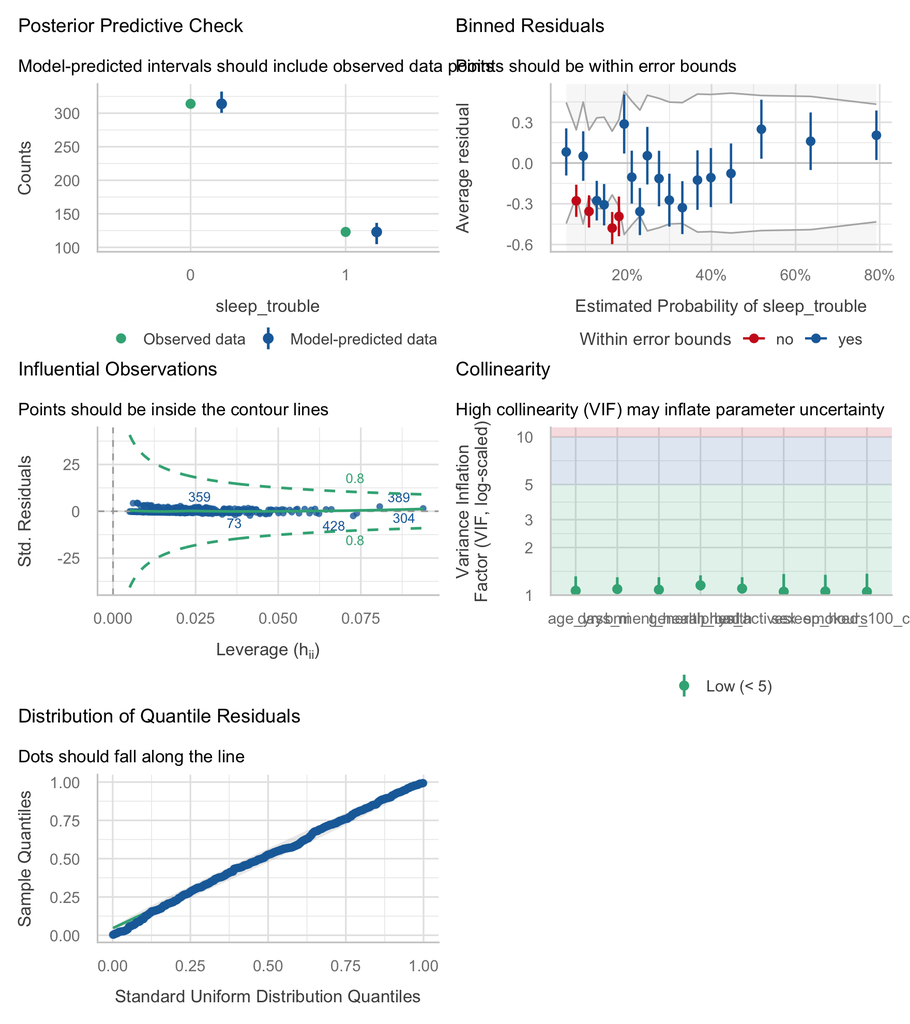

| Term | VIF | VIF_CI_low | VIF_CI_high | SE_factor | Tolerance | Tolerance_CI_low | Tolerance_CI_high |
| --- | --- | --- | --- | --- | --- | --- | --- |
| age_yrs | 1.066200 | 1.013938 | 1.314433 | 1.032570 | 0.9379101 | 0.7607844 | 0.9862539 |
| sex | 1.051768 | 1.007427 | 1.360844 | 1.025557 | 0.9507800 | 0.7348383 | 0.9926279 |
| bmi | 1.092380 | 1.028725 | 1.297101 | 1.045170 | 0.9154320 | 0.7709497 | 0.9720774 |
| days_ment_health_bad | 1.082705 | 1.022915 | 1.298505 | 1.040531 | 0.9236127 | 0.7701164 | 0.9775988 |
| general_health | 1.154070 | 1.071096 | 1.333878 | 1.036473 | 0.8664988 | 0.7496937 | 0.9336229 |
| phys_active | 1.100532 | 1.033861 | 1.298475 | 1.049063 | 0.9086512 | 0.7701341 | 0.9672478 |
| smoked_100_cigs | 1.050913 | 1.007092 | 1.365526 | 1.025141 | 0.9515534 | 0.7323187 | 0.9929584 |
| sleep_hours | 1.055348 | 1.008898 | 1.344296 | 1.027301 | 0.9475544 | 0.7438837 | 0.9911808 |

# Discussion

**Limitations.** The models are unweighted, and the NHANES sampling weights, strata and PSUs are not in this extract, so the sample **must not be described as nationally representative**. The outcome is not “has a sleep disorder” but “has *told a doctor* about trouble sleeping”, which mixes the underlying condition with help-seeking behaviour and access to care; women and people with regular healthcare contact are more likely to have had that conversation, so the sex coefficient in particular is partly a care-seeking effect rather than a prevalence difference. The design is cross-sectional, and the mental-health association is almost certainly bidirectional - insomnia causes distress as readily as distress causes insomnia - so it cannot be given a direction here. `days_ment_health_bad` is heavily zero-inflated and is modelled as linear on the log-odds scale, which the binned-residual check suggests is imperfect. Complete-case analysis dropped 51 of 488 rows (10%), almost all because self-rated health and mental-health days are missing together for the same participants, and people who skip health-perception questions are unlikely to be a random subset. All estimates are associations, not causal effects.

**Future work.** Refit with the NHANES survey design, and use a validated insomnia instrument rather than a help-seeking question as the outcome.

# Feasibility notes

*NOT part of a student report.*